# Han-BanningGamblingLivestreams-2024-SSRN.pdf

#### **D.2 Robustness of Main Results**

gambling contents are -1.001 and -0.130 respectively for the two treated groups. Plugging these

estimates into Proposition 3, We get

**equation / math rendering (image)**

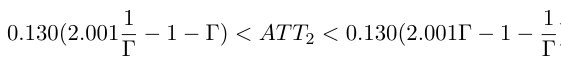

NOTE: contains mathematical notation; text above is the PDF text layer and symbols may be mis-extracted. Image shows the original.

Based on the above result, we are confident with the result that the banning policy led to a

reduction in the supply of gambling content of unbanned streamers as long as

0*.*130(2*.*001Γ *−*1 *−*<sup>1</sup> Γ<sup>)</sup>*<sup><</sup>*<sup>0</sup>*<sup>⇔</sup>*<sup>Γ</sup>*<sup>∈</sup>*<sup>(0</sup>*<sup>,</sup>*<sup>0</sup>*<sup>.</sup>*<sup>999)</sup>

i.e. the fraction of misclassified banned streamers in our observed unbanned group is less than

approximately 50%. Similarly, the range of sensitivity parameters for the estimates in Table 6

are (0*,* 2*.*427) and (0*,* 1*.*465) respectively. Therefore, both of them are robust to misclassification

as long as the fraction of misclassified banned streamers in our observed unbanned group is less

than approximately 50%.

#### **D.3 Proofs for Appendix D**

#### **D.3.1 Proof of Proposition 1**

Note that

*βDiD,*1 = E[*Y*1 *−Y*0 *| D*1 = 1*, D*2 = 0] *−*E[*Y*1 *−Y*0 *| D*1 = 0*, D*2 = 0]

**equation / math rendering (image)**

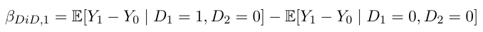

NOTE: contains mathematical notation; text above is the PDF text layer and symbols may be mis-extracted. Image shows the original.

= (E[*Y*1 *| D*1 = 1*, D*2 = 0] *−*E[*Y*1 *| D*1 = 0*, D*2 = 0])

**equation / math rendering (image)**

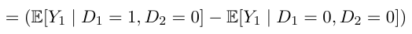

NOTE: contains mathematical notation; text above is the PDF text layer and symbols may be mis-extracted. Image shows the original.

*−*(E[*Y*0 *| D*1 = 1*, D*2 = 0] *−*E[*Y*0 *| D*1 = 0*, D*2 = 0])

**equation / math rendering (image)**

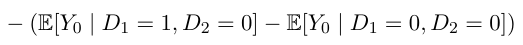

NOTE: contains mathematical notation; text above is the PDF text layer and symbols may be mis-extracted. Image shows the original.

Plugging the expression of *Yt* from (9), we have

E[*Y*1 *| D*1 = 1*, D*2 = 0] *−*E[*Y*1 *| D*1 = 0*, D*2 = 0]

**equation / math rendering (image)**

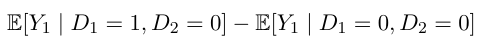

NOTE: contains mathematical notation; text above is the PDF text layer and symbols may be mis-extracted. Image shows the original.

= E[*Y*1(1*,* 0)*D<sup>∗</sup>*

**equation / math rendering (image)**

NOTE: contains mathematical notation; text above is the PDF text layer and symbols may be mis-extracted. Image shows the original.

**equation / math rendering (image)**

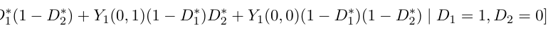

NOTE: contains mathematical notation; text above is the PDF text layer and symbols may be mis-extracted. Image shows the original.

*−*E[*Y*1(1*,* 0)*D<sup>∗</sup>*

**equation / math rendering (image)**

NOTE: contains mathematical notation; text above is the PDF text layer and symbols may be mis-extracted. Image shows the original.

1<sup>(1</sup>*<sup>−</sup><sup>D</sup><sup>∗</sup>* 2<sup>) +</sup>*<sup>Y</sup>*<sup>1</sup><sup>(0</sup>*<sup>,</sup>*<sup>1)(1</sup>*<sup>−</sup><sup>D</sup><sup>∗</sup>* 1<sup>)</sup>*<sup>D</sup><sup>∗</sup>* 2 <sup>+</sup>*<sup>Y</sup>*<sup>1</sup><sup>(0</sup>*<sup>,</sup>*<sup>0)(1</sup>*<sup>−</sup><sup>D</sup><sup>∗</sup>* 1<sup>)(1</sup>*<sup>−</sup><sup>D</sup><sup>∗</sup>* 2<sup>)</sup>*<sup>|</sup><sup>D</sup>*<sup>1</sup> <sup>= 0</sup>*<sup>, D</sup>*<sup>2</sup> <sup>= 0]</sup>

**equation / math rendering (image)**

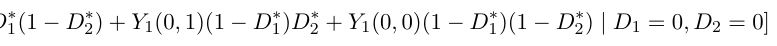

NOTE: contains mathematical notation; text above is the PDF text layer and symbols may be mis-extracted. Image shows the original.

= E[(*Y*1(1*,* 0) *−Y*1(0*,* 0)*D*1)*D<sup>∗</sup>*

**equation / math rendering (image)**

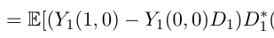

NOTE: contains mathematical notation; text above is the PDF text layer and symbols may be mis-extracted. Image shows the original.

1<sup>(1</sup>*<sup>−</sup><sup>D</sup><sup>∗</sup>* 2<sup>) + (</sup>*<sup>Y</sup>*<sup>1</sup><sup>(0</sup>*<sup>,</sup>*<sup>1)</sup>*<sup>−</sup><sup>Y</sup>*<sup>1</sup><sup>(0</sup>*<sup>,</sup>*<sup>0))(1</sup>*<sup>−</sup><sup>D</sup><sup>∗</sup>* 1<sup>)</sup>*<sup>D</sup><sup>∗</sup>* 2

**equation / math rendering (image)**

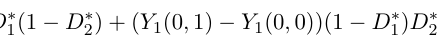

NOTE: contains mathematical notation; text above is the PDF text layer and symbols may be mis-extracted. Image shows the original.

+ *Y*1(0*,* 0)(1 *−D<sup>∗</sup>*

**equation / math rendering (image)**

NOTE: contains mathematical notation; text above is the PDF text layer and symbols may be mis-extracted. Image shows the original.

1*<sup>D</sup><sup>∗</sup>* 2<sup>)</sup>*<sup>|</sup><sup>D</sup>*<sup>1</sup> <sup>= 1</sup>*<sup>, D</sup>*<sup>2</sup> <sup>= 0]</sup>

**equation / math rendering (image)**

NOTE: contains mathematical notation; text above is the PDF text layer and symbols may be mis-extracted. Image shows the original.

*−*E[(*Y*1(1*,* 0) *−Y*1(0*,* 0)*D*1)*D<sup>∗</sup>*

**equation / math rendering (image)**

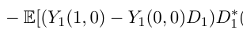

NOTE: contains mathematical notation; text above is the PDF text layer and symbols may be mis-extracted. Image shows the original.

1<sup>(1</sup>*<sup>−</sup><sup>D</sup><sup>∗</sup>* 2<sup>) + (</sup>*<sup>Y</sup>*<sup>1</sup><sup>(0</sup>*<sup>,</sup>*<sup>1)</sup>*<sup>−</sup><sup>Y</sup>*<sup>1</sup><sup>(0</sup>*<sup>,</sup>*<sup>0))(1</sup>*<sup>−</sup><sup>D</sup><sup>∗</sup>* 1<sup>)</sup>*<sup>D</sup><sup>∗</sup>* 2

**equation / math rendering (image)**

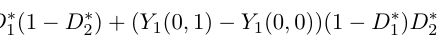

NOTE: contains mathematical notation; text above is the PDF text layer and symbols may be mis-extracted. Image shows the original.

+ *Y*1(0*,* 0)(1 *−D<sup>∗</sup>*

**equation / math rendering (image)**

NOTE: contains mathematical notation; text above is the PDF text layer and symbols may be mis-extracted. Image shows the original.

1*<sup>D</sup><sup>∗</sup>* 2<sup>)</sup>*<sup>|</sup><sup>D</sup>*<sup>1</sup> <sup>= 0</sup>*<sup>, D</sup>*<sup>2</sup> <sup>= 0]</sup>

**equation / math rendering (image)**

NOTE: contains mathematical notation; text above is the PDF text layer and symbols may be mis-extracted. Image shows the original.

= E[*Y*1(1*,* 0) *−Y*1(0*,* 0) *| D<sup>∗</sup>*

**equation / math rendering (image)**

NOTE: contains mathematical notation; text above is the PDF text layer and symbols may be mis-extracted. Image shows the original.

1 <sup>= 1</sup>*<sup>, D</sup><sup>∗</sup>* 2 <sup>= 0</sup>*<sup>, D</sup>*<sup>1</sup> <sup>= 0</sup>*<sup>, D</sup>*<sup>2</sup> <sup>= 0]</sup>*<sup>P</sup>*<sup>(</sup>*<sup>D</sup><sup>∗</sup>* 1 <sup>= 1</sup>*<sup>, D</sup><sup>∗</sup>* 2 <sup>= 0</sup>*<sup>|</sup><sup>D</sup>*<sup>1</sup> <sup>= 1</sup>*<sup>, D</sup>*<sup>2</sup> <sup>= 0)</sup>

**equation / math rendering (image)**

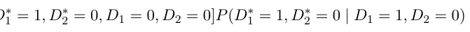

NOTE: contains mathematical notation; text above is the PDF text layer and symbols may be mis-extracted. Image shows the original.

**equation / math rendering (image)**

NOTE: contains mathematical notation; text above is the PDF text layer and symbols may be mis-extracted. Image shows the original.

**equation / math rendering (image)**

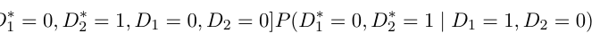

NOTE: contains mathematical notation; text above is the PDF text layer and symbols may be mis-extracted. Image shows the original.

**equation / math rendering (image)**

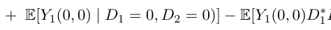

NOTE: contains mathematical notation; text above is the PDF text layer and symbols may be mis-extracted. Image shows the original.

**equation / math rendering (image)**

NOTE: contains mathematical notation; text above is the PDF text layer and symbols may be mis-extracted. Image shows the original.

**equation / math rendering (image)**

NOTE: contains mathematical notation; text above is the PDF text layer and symbols may be mis-extracted. Image shows the original.

**equation / math rendering (image)**

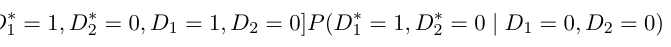

NOTE: contains mathematical notation; text above is the PDF text layer and symbols may be mis-extracted. Image shows the original.

**equation / math rendering (image)**

NOTE: contains mathematical notation; text above is the PDF text layer and symbols may be mis-extracted. Image shows the original.

**equation / math rendering (image)**

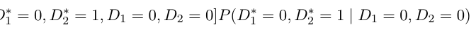

NOTE: contains mathematical notation; text above is the PDF text layer and symbols may be mis-extracted. Image shows the original.

**equation / math rendering (image)**

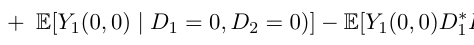

NOTE: contains mathematical notation; text above is the PDF text layer and symbols may be mis-extracted. Image shows the original.

**equation / math rendering (image)**

NOTE: contains mathematical notation; text above is the PDF text layer and symbols may be mis-extracted. Image shows the original.

**equation / math rendering (image)**

NOTE: contains mathematical notation; text above is the PDF text layer and symbols may be mis-extracted. Image shows the original.

**equation / math rendering (image)**

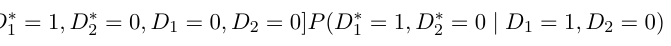

NOTE: contains mathematical notation; text above is the PDF text layer and symbols may be mis-extracted. Image shows the original.

**equation / math rendering (image)**

NOTE: contains mathematical notation; text above is the PDF text layer and symbols may be mis-extracted. Image shows the original.

**equation / math rendering (image)**

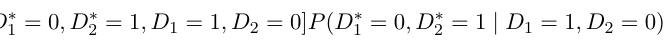

NOTE: contains mathematical notation; text above is the PDF text layer and symbols may be mis-extracted. Image shows the original.

**equation / math rendering (image)**

NOTE: contains mathematical notation; text above is the PDF text layer and symbols may be mis-extracted. Image shows the original.

**equation / math rendering (image)**

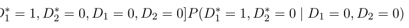

NOTE: contains mathematical notation; text above is the PDF text layer and symbols may be mis-extracted. Image shows the original.

**equation / math rendering (image)**

NOTE: contains mathematical notation; text above is the PDF text layer and symbols may be mis-extracted. Image shows the original.

**equation / math rendering (image)**

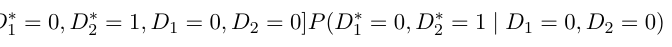

NOTE: contains mathematical notation; text above is the PDF text layer and symbols may be mis-extracted. Image shows the original.

(11)

whereas the last equality holds under Assumption 1 and the fact that

**equation / math rendering (image)**

NOTE: contains mathematical notation; text above is the PDF text layer and symbols may be mis-extracted. Image shows the original.

**equation / math rendering (image)**

NOTE: contains mathematical notation; text above is the PDF text layer and symbols may be mis-extracted. Image shows the original.

60

Page 61

under Assumption 2. The decomposition of *βDiD,*2 can be obtained similarly. □

#### **D.3.2 Proof of Proposition 2**

The results are derived directly by plugging the bounds of conditional probabilities into results

of Proposition 10. □

#### **D.3.3 Proof of Proposition 3**

Note that with model (9), there will be no misclassification in the untreated group, i.e.

**equation / math rendering (image)**

NOTE: contains mathematical notation; text above is the PDF text layer and symbols may be mis-extracted. Image shows the original.

**equation / math rendering (image)**

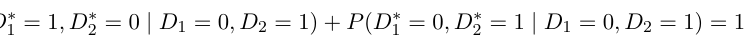

NOTE: contains mathematical notation; text above is the PDF text layer and symbols may be mis-extracted. Image shows the original.

correct classification conditional on actual second treatment:

**equation / math rendering (image)**

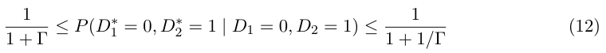

NOTE: contains mathematical notation; text above is the PDF text layer and symbols may be mis-extracted. Image shows the original.

Therefore,

**equation / math rendering (image)**

NOTE: contains mathematical notation; text above is the PDF text layer and symbols may be mis-extracted. Image shows the original.

**equation / math rendering (image)**

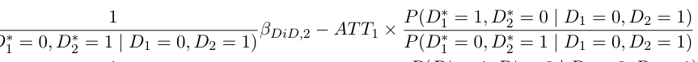

NOTE: contains mathematical notation; text above is the PDF text layer and symbols may be mis-extracted. Image shows the original.

**equation / math rendering (image)**

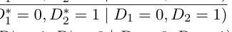

NOTE: contains mathematical notation; text above is the PDF text layer and symbols may be mis-extracted. Image shows the original.

**equation / math rendering (image)**

NOTE: contains mathematical notation; text above is the PDF text layer and symbols may be mis-extracted. Image shows the original.

**equation / math rendering (image)**

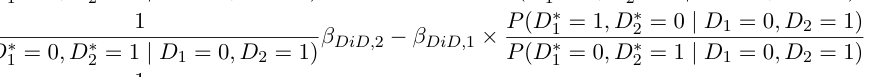

NOTE: contains mathematical notation; text above is the PDF text layer and symbols may be mis-extracted. Image shows the original.

**equation / math rendering (image)**

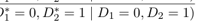

NOTE: contains mathematical notation; text above is the PDF text layer and symbols may be mis-extracted. Image shows the original.

**equation / math rendering (image)**

NOTE: contains mathematical notation; text above is the PDF text layer and symbols may be mis-extracted. Image shows the original.

**equation / math rendering (image)**

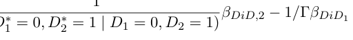

NOTE: contains mathematical notation; text above is the PDF text layer and symbols may be mis-extracted. Image shows the original.

*≤*(1 + Γ)*βDiD,*2 *−*1*/*Γ*βDiD,*1

**equation / math rendering (image)**

NOTE: contains mathematical notation; text above is the PDF text layer and symbols may be mis-extracted. Image shows the original.

when *βDiD,d >* 0 for *d* = 1*,* 2. The lower bound of *ATT*2 when *βDiD,d >* 0 and the bounds when

*βDiD,d <* 0 can be obtained similarly. □

61

Page 62

### **E Network Analysis**

Table E.0.1: Community Clusters and Treatment Status (Part 1)

[output not shown]

NOTE: table converted from PDF layout to HTML text; cell boundaries are reconstructed. See PDF if exact alignment matters.

62

Page 63

Table E.0.2: Community Clusters and Treatment Status (Part 2)

[output not shown]

NOTE: table converted from PDF layout to HTML text; cell boundaries are reconstructed. See PDF if exact alignment matters.

*Notes*: This table presents the 52 communities detected by the Louvain Community Detection algorithm. For each community cluster, we show the number of streamers within the cluster and the share of streamers of different treatment status. Note that some clusters consist of streamers of one treatment status, while others are mixed. We discuss the streamers and communities used in our constructed treated and untreated groups for SUTVA alleviation in Section 8.2.

63